# Introduction to Unsupervised Learning and Principal Components

John Mayberry

2025-03-18

## Introduction: Supervised vs. Unsupervised Methods

Thus far in the course, all of our examples have taken the following flavor: we have some response variable $Y$ and some set of predictors $X_1,...,X_p$ which we want to use to predict $Y$. If $Y$ is numeric, we can use OLS or one of its cousins (subset selection, lasso, etc). This is called a regression problem. If $Y$ is categorical, we can use logistic regression (or KNN) and this is called a classification problem. But both regression and classification problems fall under the framework of supervised methods because models are fit based on a pre-specified target of responses.

In contrast, unsupervised methods apply when you don’t know the $Y$. In such scenarios, the goal is to identify appropriate ways of grouping predictors. For example (stolen from the book), Amazon may want to group together users based on past purchase histories and then target each group with a specific recommended product. We will discuss two types of unsupervised methods:

- Principal Component Analysis (PCA) where samples are grouped based on principal component scores
- Cluster Analysis where items are grouped based on similarities in variable measurements

These notes will focus on the former because it also provides a smooth transition from the topic of last module as it is often used for dimension reduction.

## Idea behind principal componets

We have frequently used the election2016 data set as an example of supervised learning using both the trump.vote proportion and outcome (red or blue) as response variables. But suppose our interest instead is not to predict, but just to group like states together for the purposes of political or economic planning. Is there a simple way of doing so based on the eight demographic-ish variables we previously used as predictors?

Technically, the states live in eight dimensional space when looked at in this way so it might be a little hard to “see” any groupings. But as previously noted, many of the predictors are heavily correlated with each other:

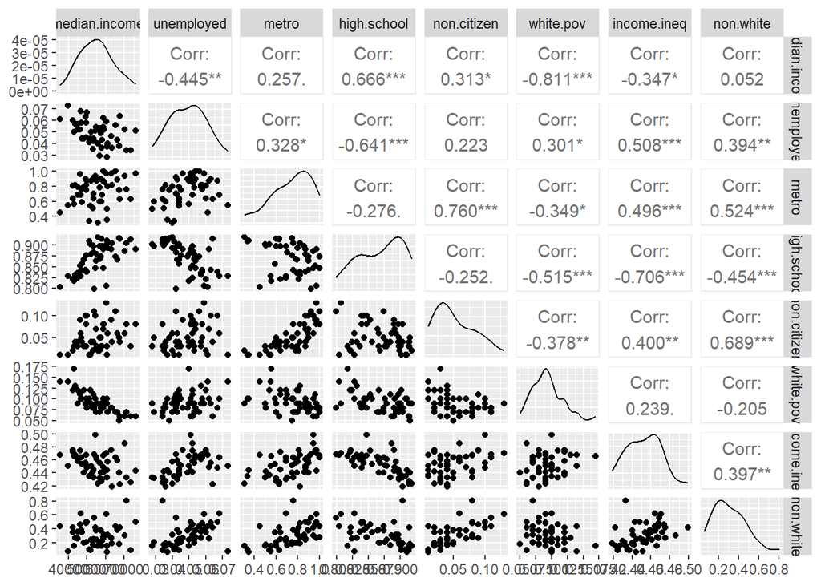

```r
library(GGally)
ggpairs(election2016[,2:9])
```

A correlation plot is also helpful for visualizing this

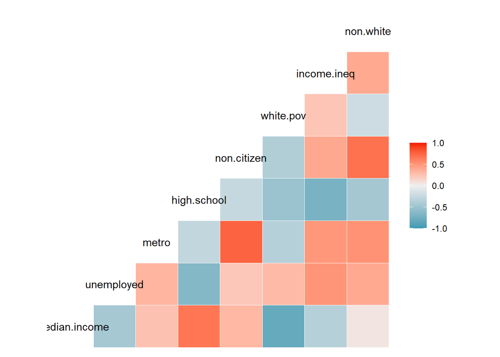

```r
ggcorr(election2016[,2:9])
```

Looking at these graphics we can see, for example, that there is are very high positive correlation between non.white, non.citizen, and metro. Does it make sense to include all three variables in our model or is there a single variables (such as the average of the three) which might be sufficient to capture their combined effect?

Principal Component Analysis (PCA) attempts to find “optimal” linear combinations of predictors to use as alternative features in a linear model. In other words, PCA attempts to replace a set of predictors $X_1,..,X_p$ with a new set of variables $U_1,..,U_q$ such that the $U_i$ capture the essential information about the $X_i$s but with a fewer number $q < p$ variables. Whereas the original predictors $X_i$ may have correlations, we would like the $U_i$ to be uncorrelated with each other so that each is capturing as much of the variance in features as possible.

## Example with two predictors

Let’s start by illustrating this idea with the two variables non.white and non.citizen. Our goal will be to represent each observation (non.white,non.citizen) in a new orthogonal coordinate system $(u_1,u_2)$ such that the first coordinate captures as much of the spread as possible while the second coordinate picks up the remainder. In other words, we would like to create a new set of orthogonal directions for getting to a particular (non.white,non.citizen) pair which goes as far as possible in the first step and then only has minimal distance to travel in the second step. Amazingly, the choice of directions ends up being based on the least squares line.

Hopefully, a visual will help better explain this idea. First, here is a scatterplot of non.white vs non.citizen with the least squares line

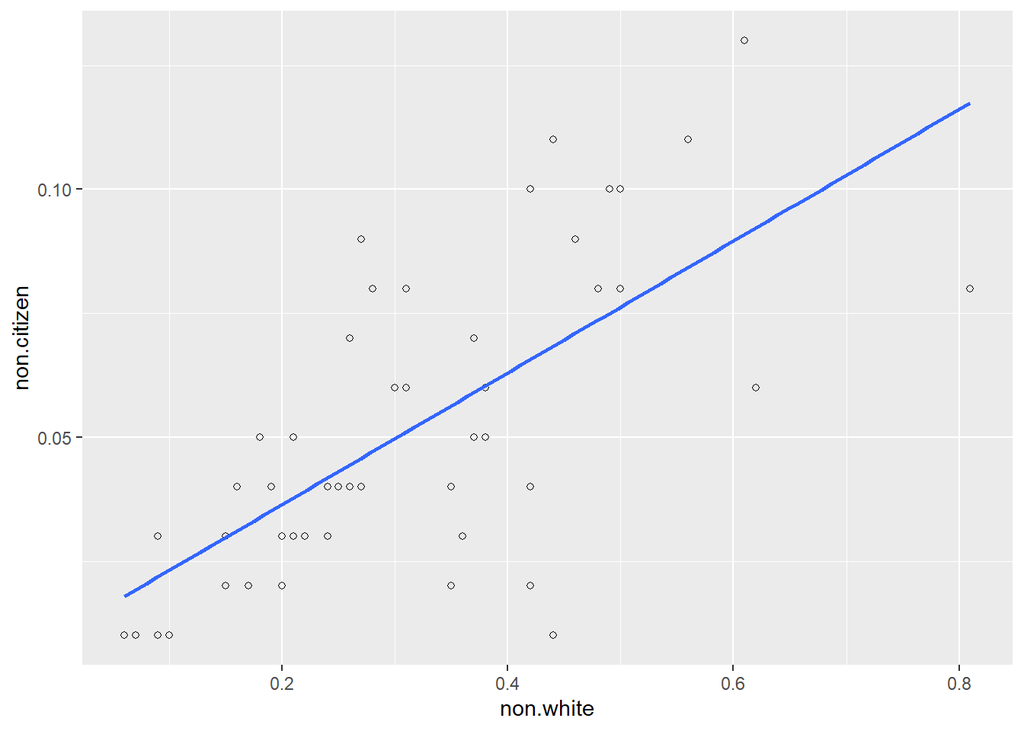

```r
ggplot(election2016,aes(x=non.white,y=non.citizen))+
  geom_point(shape=1)+geom_smooth(method=lm,se=FALSE)
```

Now suppose we “center” the two variables (so that the mean is at the origin) and also show the line orthogonal to the least squares one:

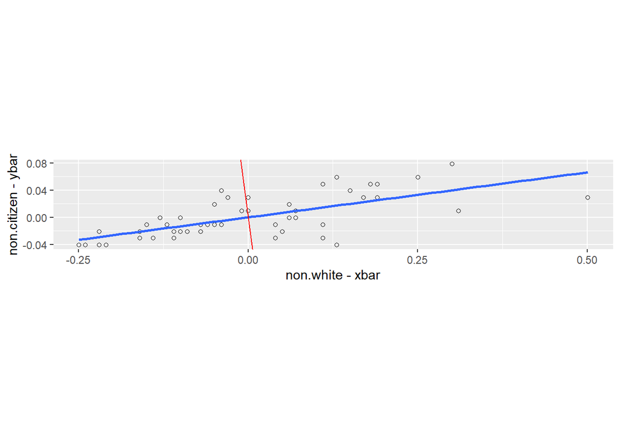

```r
xbar=mean(election2016$non.white)
ybar=mean(election2016$non.citizen)
m=coef(lm(non.citizen~non.white,data=election2016))[2]
ggplot(election2016,aes(x=non.white-xbar,y=non.citizen-ybar))+
  geom_point(shape=1)+geom_smooth(method=lm,se=FALSE)+
  geom_abline(slope=-1/m,color="red")+coord_fixed()
```

I just want to reach in there and rotate this so that the blue line is the new x-axis and the red is the new y. This type of transformation is called a change of basis in Linear Algebra and it is the basis of PCA (pun totally intended).

Changing bases allows us to give directions to a particular point $(x_1,x_2)$ in new ways. Instead of “travel $x_1$ units left and $x_2$ units right”, we can travel $u_1$ units in the direction of the blue line and then $u_2$ in the direction of the red. For the data above, this seems more efficient: the blue direction covers more of the “spread” or “variance” in the data while the red helps get us the rest of the way home.

The coordinates $(u_1,u_2)$ are called the Principal Component Scores of $(x_1,x_2)$ while the directions given by the blue and red lines are the first and second principal components. Both the first and second principal components $U_j$ are linear combinations of $X_1,X_2$ so
$$U_j = v_{1j} X_1 + v_{2j} X_2$$
where here, $X_1,X_2$ refer to the centered versions of non.white and non.citizen. The coefficients $v_{ij}$ are called the loadings. They can be calculated using the princomp function.

```r
pcs=princomp(election2016[,c("non.white","non.citizen")])
pcs$loadings
```

```
##
## Loadings:
##             Comp.1 Comp.2
## non.white    0.991  0.134
## non.citizen  0.134 -0.991
##
##                Comp.1 Comp.2
## SS loadings       1.0    1.0
## Proportion Var    0.5    0.5
## Cumulative Var    0.5    1.0
```

The output here means that the first principal components loadings (column Comp.1 of the first matrix) are 0.9909546, 0.1341973. More specifically, this means that
$$PC_1 =
0.991*(non.white-mean(non.white))+0.134*(non.citizen-mean(non.citizen))$$

Similarly, the loadings for the second principal component are given by the second column of the loadings matrix. Notice that $PC_1, PC_2$ are orthogonal (the dot product of their loading vectors is 0) which is the geometric equivalent of uncorrelated. One can also get the PC values for the original points using scores

```r
head(pcs$score)
```

```
##            Comp.1       Comp.2
## [1,]  0.036072643  0.036168003
## [2,]  0.108123413  0.025742719
## [3,]  0.185542074 -0.024320750
## [4,] -0.050429329  0.004271156
## [5,]  0.308482548 -0.037945717
## [6,]  0.001802348 -0.008838073
```

These show the transformed coordinates for each observation in the dataset. For example, looking at the first state in our dataset

```r
election2016[1,c("state","non.white","non.citizen")]
```

```
## # A tibble: 1 × 3
##   state   non.white non.citizen
##   <chr>       <dbl>       <dbl>
## 1 Alabama      0.35        0.02
```

This state has been transformed to the new coordinates

```r
pcs$scores[1,]
```

```
##     Comp.1     Comp.2
## 0.03607264 0.03616800
```

As previously mentioned, one goal of principal components is to describe as much of the variance in our data as possible from as few components as possible. In our present example, we can look at the percentage of total variance explained by each of our principal components using the summary function

```r
summary(pcs)
```

```
## Importance of components:
##                           Comp.1     Comp.2
## Standard deviation     0.1601080 0.02200152
## Proportion of Variance 0.9814666 0.01853339
## Cumulative Proportion  0.9814666 1.00000000
```

Comp.1 explains over 98% of the variance in (non.white,non.citizen) measurements therefore these two variables can likely be summarized by the single variables whose value is their first principal component[^1].

## Many become fewer

We can easily extend this idea to more than two predictors. For example, let’s look at the full principal component decomposition for our predictors in the election2016 dataset. Note that here we are adding the “cor=TRUE” command which scales each variable prior to computing the principal components. This is important here because the variable median.income is on a completely different scale than the other variables and would dominate the PCs if not scaled.

```r
pcs=princomp(election2016[,2:9],cor=TRUE)
summary(pcs)
```

```
## Importance of components:
##                          Comp.1    Comp.2     Comp.3     Comp.4    Comp.5
## Standard deviation     1.854314 1.6546539 0.74949921 0.69703382 0.5492409
## Proportion of Variance 0.429810 0.3422350 0.07021863 0.06073202 0.0377082
## Cumulative Proportion  0.429810 0.7720449 0.84226356 0.90299558 0.9407038
##                           Comp.6     Comp.7     Comp.8
## Standard deviation     0.4417954 0.39267772 0.35354029
## Proportion of Variance 0.0243979 0.01927447 0.01562384
## Cumulative Proportion  0.9651017 0.98437616 1.00000000
```

Notice that the first PC describes only about 43% of the predictor variance between states, but keep in mind that we are now trying to summarize eight variables with one so that’s better than the 12.5% we would get by just randomly choosing one of eight directions! The first two principal components together explain more than 77% of the variance in all eight variables which is a pretty good reduction in dimension. After that, we don’t gain much per additional component. Therefore, we may be able to summarize all eight predictors with just those first two specially chosen linear combinations given by PC1 and PC2. Let’s look at how those first two components are related to our original variables.

```r
pcs$loadings[,1:2]
```

```
##                   Comp.1      Comp.2
## median.income  0.2294226  0.50908385
## unemployed    -0.4076582 -0.12432567
## metro         -0.3309666  0.38102910
## high.school    0.4672132  0.21826194
## non.citizen   -0.3145470  0.42467308
## white.pov     -0.1418063 -0.52853410
## income.ineq   -0.4455115 -0.03160487
## non.white     -0.3685426  0.26806889
```

Notice the first principal component has a large positive coefficient for high.school, a smaller positive coefficient for median.income, and negative coefficients on all of the other variables. Therefore, a state with high PC1 would have higher median income and high school graduation rates than your typical state, but below average everything else. Ignoring white.pov which had a relatively small coefficient in absolute value, the coefficient sizes are similar. So a state with high PC1 is a wealthier, more educated state with low unemployment that also happens to be pretty white and rural and homogeneous in terms of income inequality. PC2, in contrast, places positive values on everything except white.pov (and unemployed/income.ineq which are pretty small). So states with high PC2 would be wealthy and diverse metro states with low levels of white poverty. Let’s look at a plot of the PC scores by states

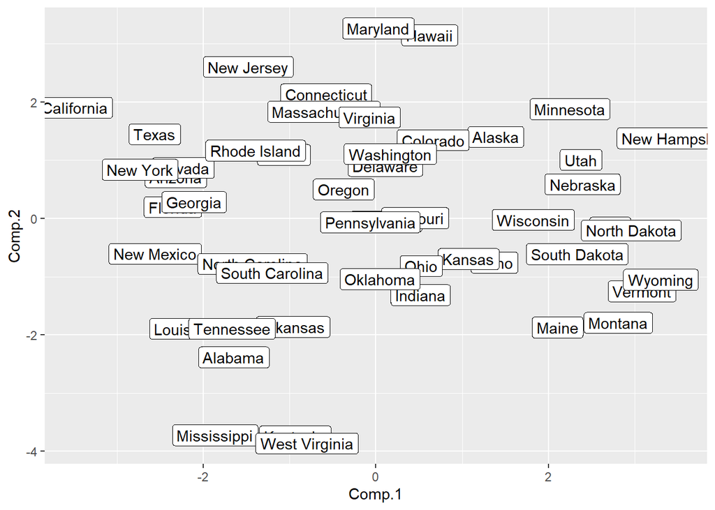

```r
electionPC=cbind(election2016,pcs$scores[,1:2])
ggplot(electionPC,aes(x=Comp.1,y=Comp.2,label=state))+geom_point(shape=1)+geom_label()
```

How do our observations about the meaning of the principal components match up with what you know about the states? We leave it to the reader to decide (and we will also discuss in class).

## How is PCA unsupervised learning?

So far, what we have done is start to visually group states together based on where they lay in this two-dimensional plot. Let’s do something a little more concrete by placing groups into “clusters” based on which quadrant they fall in:

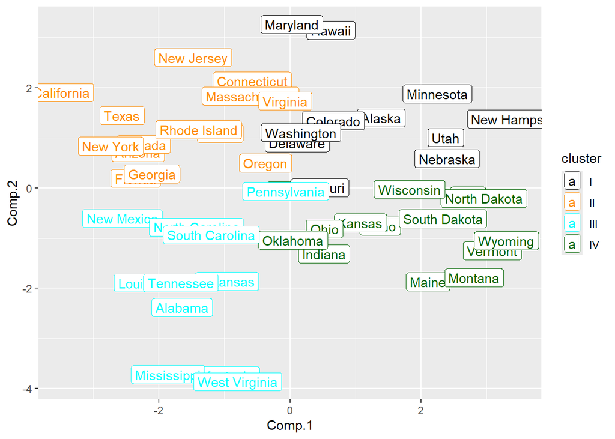

```r
electionPC$cluster=ifelse(electionPC$Comp.1>0&electionPC$Comp.2>0,"I",
                          ifelse(electionPC$Comp.1<0&electionPC$Comp.2>0,"II",                                ifelse(electionPC$Comp.1<0&electionPC$Comp.2<0,"III","IV")
                                 ))
ggplot(electionPC,aes(x=Comp.1,y=Comp.2,label=state,col=cluster))+geom_point(shape=1)+geom_label()+scale_color_manual(values=c("black","darkorange","cyan","darkgreen"))
```

And voila, we have classified the states in some new and bizarre way. Is this useful? How the hell should I know? I’m just a mathematician. But maybe a political scientist or economist might be able to use it in some meaningful way.

## PCA as dimension reduction

PCA can also be used in feature selection, but with a very different approach. Instead of trying to choose a subset of features, it tries to reduce the number of variables by removing uneccessary correlations. For example, suppose that we use the component scores in a model for trump.vote instead of our original eight features. These can be added to the original data using the following

```r
electionPCS=cbind(election2016,pcs$scores)
names(electionPCS)
```

```
##  [1] "state"            "median.income"    "unemployed"       "metro"
##  [5] "high.school"      "non.citizen"      "white.pov"        "income.ineq"
##  [9] "non.white"        "trump.vote"       "post_hate.crimes" "pre_hate.crimes"
## [13] "outcome"          "Comp.1"           "Comp.2"           "Comp.3"
## [17] "Comp.4"           "Comp.5"           "Comp.6"           "Comp.7"
## [21] "Comp.8"
```

All eight PC score variables were added to the dataset. The full model for trump.vote had an $R^2$ value of around

```r
full_formula=as.formula(paste('trump.vote~',paste(names(election2016)[2:9],collapse="+")))
full_lm=lm(full_formula,data=election2016)
summary(full_lm)$r.squared
```

```
## [1] 0.6510282
```

Now suppose we use the first three PCs (which accounted for over 80% of the total variance):

```r
pcs_lm=lm(trump.vote~Comp.1+Comp.2+Comp.3,data=electionPCS)
summary(pcs_lm)$r.squared
```

```
## [1] 0.5354155
```

Not too much worse. If you look at the best three variable model its better though:

```r
best3_lm=lm(trump.vote~median.income+non.citizen+income.ineq,data=electionPCS)
summary(best3_lm)$r.squared
```

```
## [1] 0.573087
```

so maybe in this case dimension reduction is not the way to go. Just keep it in mind as a potentialtool to use down the road.

## Issue with PCA

The problem with using PCA for unsupervised learning is twofold. First, there are no great rules for choosing how many PCs to look at in classifying points. The book mentions one qualitative tool called a “scree” plot which plots the standard deviations of the principal components (singular values of the centered model matrix/eigenvalues of the covariance matrix) vs component number and looks for “elbows”

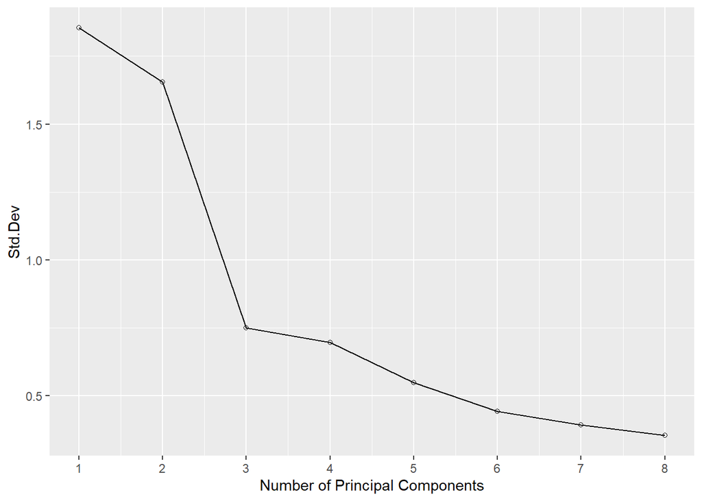

```r
scree=data.frame(Comp.Num=1:8,Std.Dev=summary(pcs)$sdev )

ggplot(scree,aes(x=Comp.Num,y=Std.Dev))+geom_point(shape=1)+geom_line()+
  scale_x_continuous(name="Number of Principal Components", breaks=1:8,label=1:8)
```

It seems like this plot has an “elbow” around PC3 so we could justify using three principal components. On the other hand, there may be another elbow around 7? In any case, you can see why this is qualitative.

A second issue with principal component analysis is deciding on boundaries between clusters of like points. For example, should Maryland, Hawaii, Washington, Delaware, and Colorado really go with the other “black” states even though they are a separate group? Clustering methods get around this issue by developing an algorithm for “combining” points into “optimal clusters.” For these reasons, other algorithms which actually have clustering in the name are often preferable. Those will be the topic of the next notes.

## Appendix: Linear Algebra Connections

Suppose that we have a set of centered vectors predictors $X_1, ...X_p$ all of length $n$ (if they are not centered, just subtract the column wise means). Define the matrix $X = \begin{bmatrix} X_1 & X_2 & \cdots & X_p\end{bmatrix}$. The singular value decomposition (SVD) of $X$ is
$$X = U \Sigma V^T$$

where $U,V$ are orthogonal matrices whose columns are called the left and right singular vectors of $X$, respectively, and $\Sigma$ is a diagonal matrix whose diagonal entries are called the singular values. This can be rewritten as
$$XV = U \Sigma$$

which has jth column

$$Xv_j = \sigma_j u_j$$

This says that the $u_j$ (scaled by $\sigma_j$) are the Principal Component scores from before (orthogonal linear combinations of the columns of $X$) and the matrix $V$ gives the loadings.

Now to understand the “proportion of variance part” requires going a little deeper. If our $X$ is $n\times p$ ($n$ data points, p predictors), then its sample covariance matrix[^2] is
$$C= \frac{1}{n-1} X^TX$$

The total variance in the $X_i$ would be the trace of this matrix: $tr(C) = \sum C_{ii}$. But also notice that
$$C = \frac{1}{n-1} X^T X = V \left(\frac{1}{n-1}\Sigma^T\Sigma\right) V^T$$

or

$$CV= V \Lambda$$

with $\Lambda = \Sigma^T\Sigma/(n-1)$. Behold, the eigenvalue-eigenvector equation emerges and the eigenvalues of $C$ are $\lambda_i = \sigma_i^2/(n-1)$: scaled versions of the singular values of $X$!

Now as a friend and colleague would say, go convince yourself this is true and as another less wise math professor would say, go fuck off.

[^1]: The proportion of variance for component $i$ is $s_i^2/\sum s_j^2$ where $s_i$ is the standard deviation - see linear algebra supplement for details.
[^2]: The $n-1$ is because we estimate the mean from the data. True we are estimating $p$ means, one for each column, but this is only one mean vector.
[^3]: There is a well know linear algebra fact that orthogonal matrices preserve trace. The proof is obvious William so don’t ask.